# rodham

John Coene

30 April 2016

# network

# setup

The package includes meta-data about the emails.

```r
data("emails")
```

# Get edges

With the dataset one can plot the network of emails using `edges_emails`.

```r
edges <- edges_emails(emails)
```

# plot network

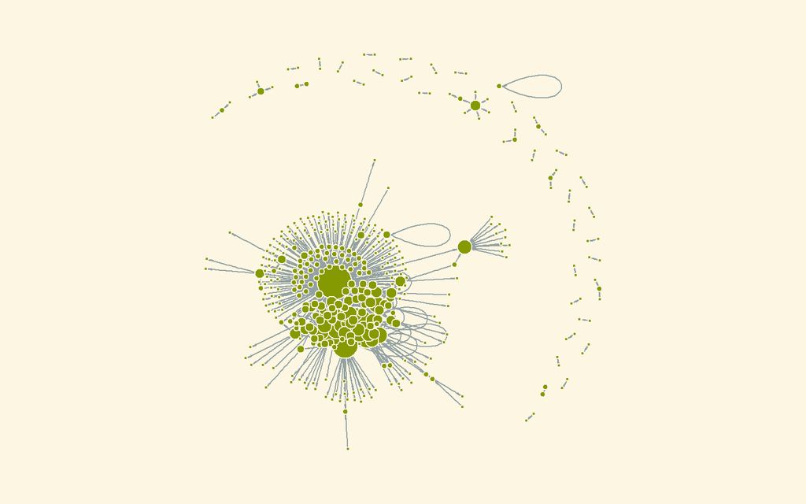

```r
g <- igraph::graph.data.frame(edges, directed = TRUE); plot(g)
```

# Subject

# Clean

We can infer the topics of emails from the subject after we’ve done some cleaning.

```r
emails$subject <- tolower(emails$subject) # to lower case
emails$subject <- trimws(emails$subject) # trim white space
emails$subject <- gsub("[[:punct:]]", "", emails$subject) # remove punctation
emails$subject <- gsub("[[:digit:]]", "", emails$subject) # remove numbers
emails$subject <- tm::removeWords(emails$subject,
                                  c(tm::stopwords("english"),
                                    "re", "fw")) # remove stopwords
```

# Count

Count term occurences.

```r
terms <- lapply(emails$subject, function(x){
  unlist(strsplit(x, " "))
})
terms <- unlist(terms)
terms <- subset(terms, terms != "")
count <- plyr::count(terms)
```

# wordcloud

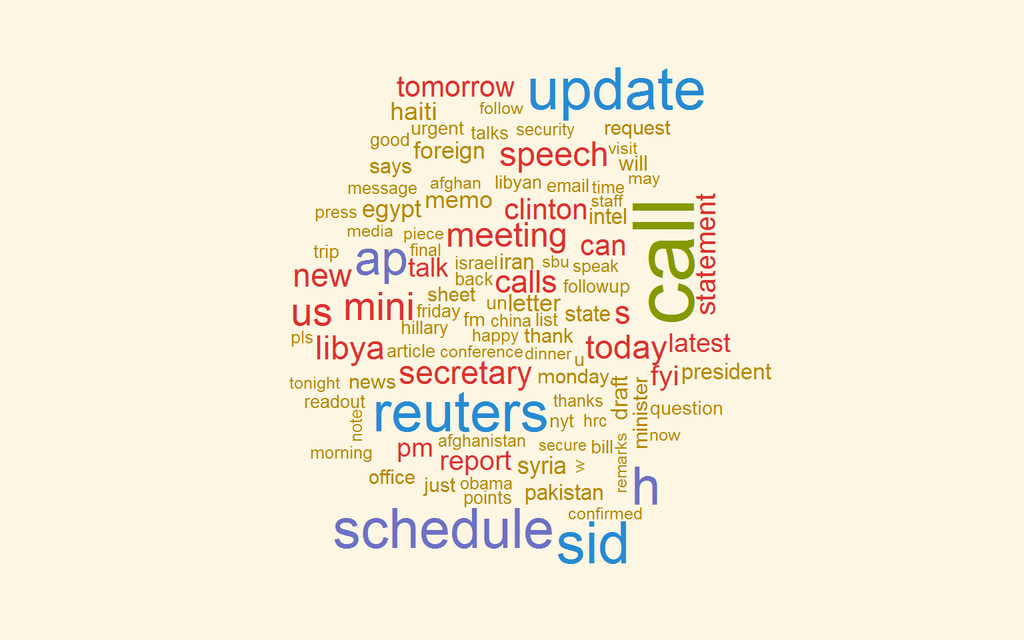

```r
wordcloud::wordcloud(count$x, count$freq, max.words = 100)
```

# grep

You can run `grep` to find out which emails refer to the terms in the wordcloud.

```r
# remmeber we converted to lower case
head(emails$subject[grep("\\blibya\\b", emails$subject)])
```

```
> [1] "tripoli libya  emergency message"
> [2] "tripoli libya  emergency message"
> [3] " libya security internal deliberations"
> [4] "h libya security latest sid"
> [5] "libya security internal deliberations"
> [6] " h libya security latest sid"
```

# Content

# xpdf

The previous slides used the package dataset which does not contain the content of the emails. To get the content of the emails we are going to need a PDF extractor. You can download xpdf manually or use `get_extractor`

```r
# save extractor in working directory
ext <- get_extractor(dest = "C:/")
```

The function returns the full path to `pdftotext.exe` to be used in the following slide.

# get emails

Now we can now get the emails. This may take some time. Zip files are downloaded, then unzipped and finally the content of each pdf (email) is extracted.

```r
emails_cuba <- get_emails(release = "Benghazi", save.dir = getwd(),
                     extractor = ext)
```

The files are extracted in our working directory in a new folder named after the release.

See `?get_emails` @details for other valid `release` values.

# read

```r
files <- list.files("benghazi", pattern = ".txt") # list files
length(files) # print number of emails
```

```
> [1] 296
```

```r
head(files, 8)
```

```
> [1] "C05739545.txt" "C05739546.txt" "C05739547.txt" "C05739550.txt"
> [5] "C05739554.txt" "C05739559.txt" "C05739560.txt" "C05739561.txt"
```

```r
# read all emails
content <- lapply(files, function(x){
  readLines(paste0("benghazi/",x))
})
```

# clean

Now we need to clean the content of emails, which are quite dirty

```r
content <- sapply(content, function(x){
  x[which(x != "")] # remove empty lines
  })
content[[1]]
```

```
>  [1] "UNCLASSIFIED U.S. Department of State Case No. F-2015-04841 Doc No. C05739545 Date: 05/13/2015"
>  [2] "STATE DEPT. - PRODUCED TO HOUSE SELECT BENGHAZI COMM. SUBJECT TO AGREEMENT ON SENSITIVE INFORMATION & REDACTIONS. NO FOIA WAIVER."
>  [3] "RELEASE IN FULL"
>  [4] "From: Sent: To: Subject:"
>  [5] "Sullivan, Jacob J <Sullivan11@state.gov> Wednesday, September 12, 2012 10:16 AM"
>  [6] "FW: Wow"
>  [7] "From: Brose, Christian (Armed Services) (mailto:Christian_Brose@armed-servic,essenate.govi Sent: Wednesday, September 12, 2012 10:09 AM To: Sullivan, Jacob J Subject: Wow"
>  [8] "What a wonderful, strong and moving statement by your boss. please tell her how much Sen. McCain appreciated it. Me too"
>  [9] "UNCLASSIFIED U.S. Department of State Case No. F-2015-04841 Doc No. C05739545 Date: 05/13/2015"
> [10] "STATE DEPT. - PRODUCED TO HOUSE SELECT BENGHAZI COMM. SUBJECT TO AGREEMENT ON SENSITIVE INFORMATION & REDACTIONS. NO FOIA WAIVER."
> [11] "STATE-5CB0045247"
```